# POLI 110: Confounding

November 13, 2025

## Confounding

## Outline

- Midterm Grades
- Recap:
  - defining of confounding
  - why confounding happens
  - causal graphs
- Recognizing Confounding
  - which additional variables generate confounding?
  - what is the direction of bias

## Midterms

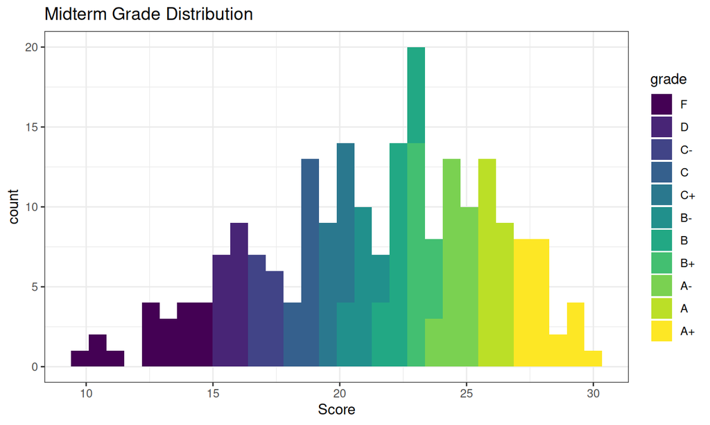

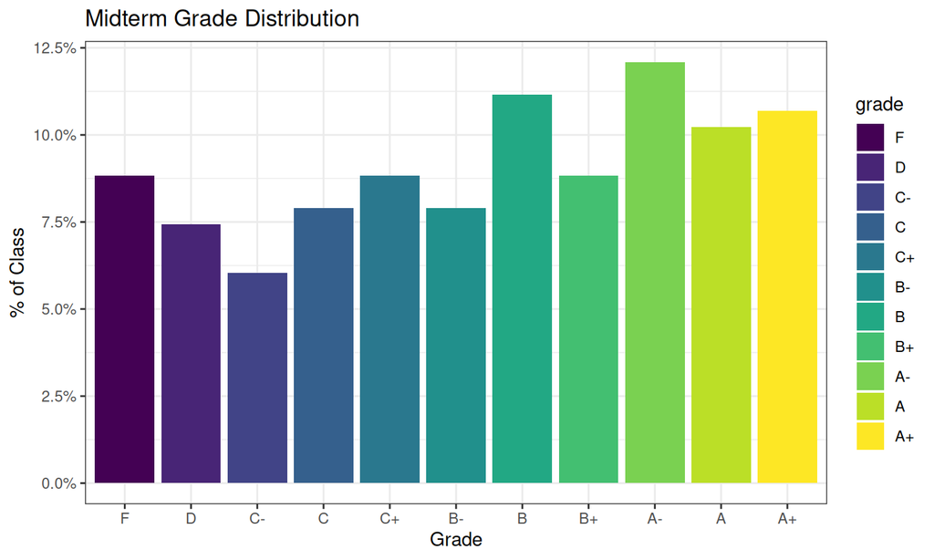

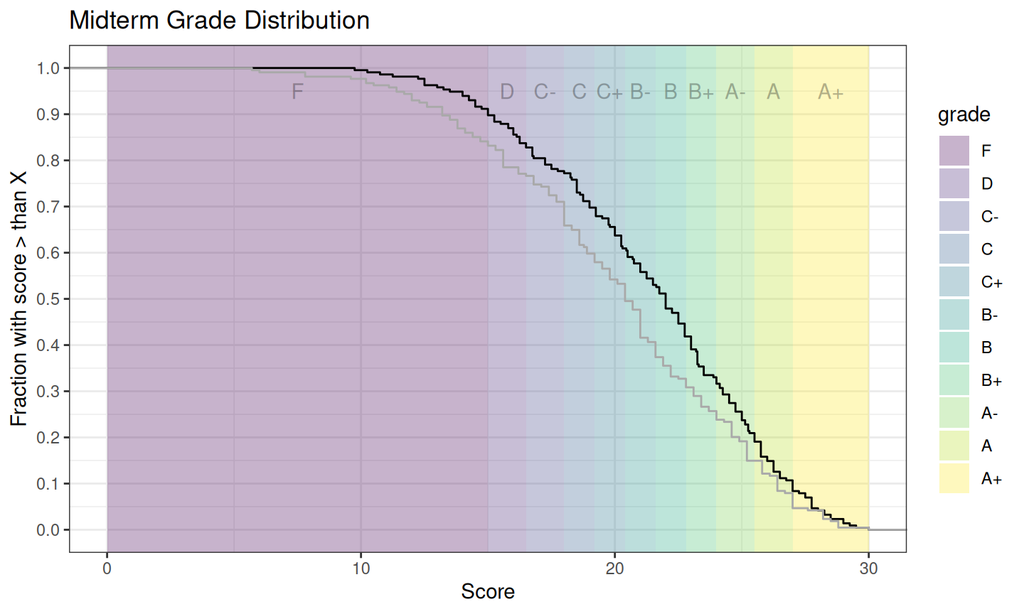

## Confounding

## Example:

> “BC’s face-mask mandate reduced COVID mortality in the province over the course of the pandemic.”
- Fundamental Problem of Causal Inference means we can’t observe BC in the counter-factual world without face-masks.

## Example:

[Karaivanov et al (2020)](https://www.nber.org/system/files/working_papers/w27891/w27891.pdf), economists at SFU, investigate:

> Did indoor mask mandates reduced COVID cases, on average? If masks reduce COVID cases, could reduce mortality.

## Example:

They compare COVID cases in Ontario Public Health Units (PHU) with and without mask mandates

- Not all Ontario PHUs imposed mask mandates at the same time
- Can compare PHUs with and without mandates
- Correlation of mask mandates and COVID cases across PHUs

## Example:

They find that PHUs with mask mandates have **slower** COVID case growth than PHUs without mask mandates…

- Is there any reason to doubt that this **correlation** is the true **causal effect** of mask mandates?

## Confounding

## Confounding

**Correlation** suffers from two sources of error:

**random error**: we observe patterns in \(X\) (independent variable) and \(Y\) (dependent variable) by chance, when there is in fact no relationship.

**confounding (bias)**: the systematic **observed correlation** between \(X\) and \(Y\) is not the **true causal effect** of \(X\) on \(Y\).

It’s summer of 2020… the correlation Karaivanov et al use effectively compares…

[figure not shown]

COVID caseload in PHUs in Toronto area (with mask mandates)…

… with COVID caseload in PHUs like North Bay (without a mask mandate)

[figure not shown]

Correlation means we “plug in” missing counterfactuals from other cases:

| Case | \(\overbrace{\text{Caseload (Mandate)}}^{Y}\) | \(\overbrace{\text{Caseload (No Mandate)}}^{Y}\) | \(\overbrace{\text{Mandate}}^{X}\) |
| --- | --- | --- | --- |
| Toronto | \(\mathrm{Cases_{Toronto}(Mandate)}\) | \(\color{red}{\mathrm{Cases_{Toronto}(No \ Mandate)}}\) | Yes |
|  | \(\Downarrow{=}\) | \(\Uparrow{=}\) |  |
| North Bay | \(\color{red}{\mathrm{Cases_{North \ Bay}(Mandate)}}\) | \(\mathrm{Cases_{North \ Bay}(No \ Mandate)}\) | No |

If this equivalence \((=)\) is false, then confounding (bias)

### Why Confounding?

Confounding occurs because:

We use outcome in case B (North Bay) to stand in for counterfactual outcome from case A (Toronto). But outcomes in case B are **not the same** as in counterfactual case A.

Two ways of thinking about why this produces a bias; unifying idea is that case A and B are **different in ways *other than* X**. These other differences affect *X* and *Y*.

### Confounding and Causal Graphs

Explanation 1: visual

Confounding occurs when there are **other differences** between cases (call them variables, e.g. \(W\), etc.) that **causally affect \(X\) and \(Y\)**.

The easiest way to understand this is **visually**.

## Causal Graphs

Causal graphs represent a model of the **true causal relationships** between variables.

the **nodes** or **dots** correspond to **variables**

- can be labeled with generic names for independent/dependent variables (\(X\), \(Y\)) or meaningful names (e.g. “Trump Tweets”, “Hate Crimes”)

the **arrows** convey the **direction** of the flow of **causality**

- \(X \rightarrow Y\) means that \(X\) causes changes in \(Y\)
- \(X \leftarrow W\) means that \(W\) causes changes in \(X\)

Arrows alone do not indicate whether \(X\), e.g., increases or decreases \(Y\).

## Causal Graphs

A *model* of true causal relationships, because:

- we don’t know the true causal relationships for sure
- graphs permit us to think whether there is confounding, **assuming a particular story** about what causes what

## Causal Graphs

### **For example**

PHUs in Toronto (that had a mask mandate) may more university educated adults than PHUs in North Bay (no mask mandate).

- University educated residents might be more likely to work from home \(\xrightarrow{causes}\) mask mandate affects fewer people \(\xrightarrow{causes}\) more likely to mandate masks
- University educated residents \(\xrightarrow{causes}\) work from home \(\xrightarrow{causes}\) fewer social contacts \(\xrightarrow{causes}\) lower COVID cases

## Causal Graphs

In a causal graph, there is **confounding** of correlation of \(X\) and \(Y\) if…

1. any variable \(W\) has a causal path (of any length) toward \(X\) and \(Y\)
2. (equivalently) there is **backdoor** path or **non-causal** path from \(X\) to \(Y\)
   - a chain of **two** or more arrows that follows arrows **backwards** from of \(X\), changes direction **once** and follows arrows **toward** \(Y\): \(X \leftarrow W \leftarrow Z \rightarrow Y\)

Confounding?

Why do backdoor paths produce confounding? Why is it systematic?

## Confounding

**Why does confounding happen?**

### **Explanation 2**:

Confounding happens when cases that experience **different levels of \(X\)** have **systematically different** (factual and counterfactual) potential outcomes of \(Y\).

- this happens because some other factor \(W\) affects \(X\) and potential outcomes of \(Y\)

Explanation 2: Other differences, Different potential outcomes

| Case | \(\overbrace{\text{Caseload (Yes)}}^{Y}\) | \(\overbrace{\text{Caseload (No)}}^{Y}\) | \(\overbrace{\text{Mandate}}^{X}\) | \(\overbrace{\text{Work from Home}}^{W}\) |
| --- | --- | --- | --- | --- |
| Toronto | \(\text{Fewer Cases}\) | \(\color{red}{\text{Fewer Cases}}\) | **Yes** | More |
|  | \(\Updownarrow{\neq}\) | \(\Updownarrow{\neq}\) |  |  |
| North Bay | \(\color{red}{\text{More Cases}}\) | \(\text{More Cases}\) | **No** | Less |

# #NotAllVariables produce confounding

## Confounding?

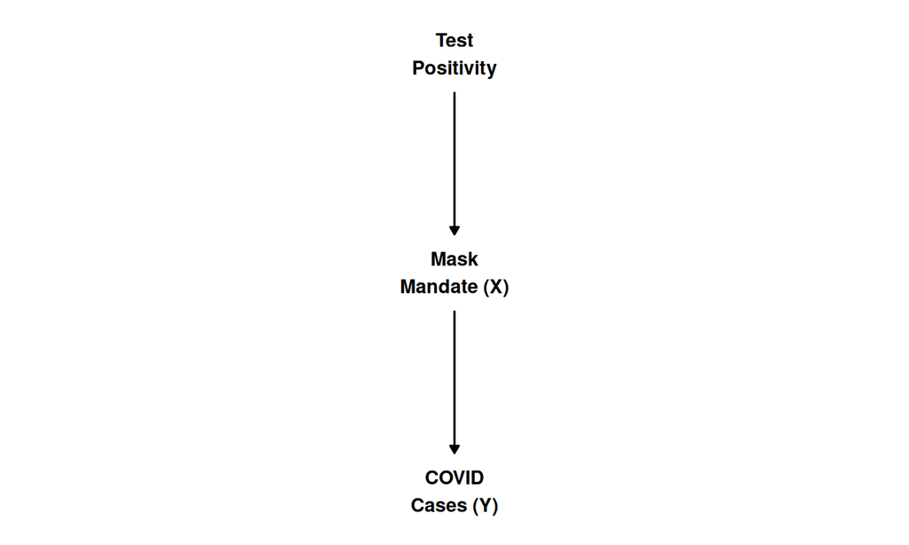

- No. No “backdoor” path.

## Antecedent Variables

**antecedent variable**: a variable that **affects** \(X\)

- e.g. in this path, \(W \xrightarrow{} X \xrightarrow{} Y\), \(W\) is an antecedent variable.
- antecedent variables (\(W\)) **do not** produce confounding if the **only causal path** from \(W\) to \(Y\) passes through \(X\).
- antecedent variables **do** produce confounding if there is another **causal path** from \(W\) to \(Y\) that does **NOT** include \(X\).

## Antecedent Variable: Confounding?

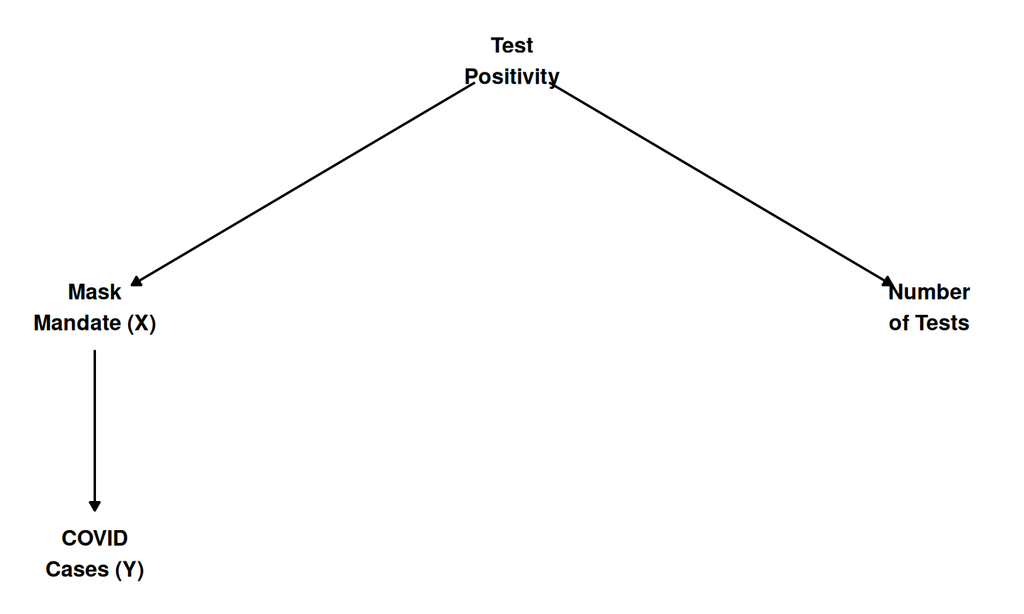

- No. No “backdoor” path.

## Antecedent Variable: Confounding?

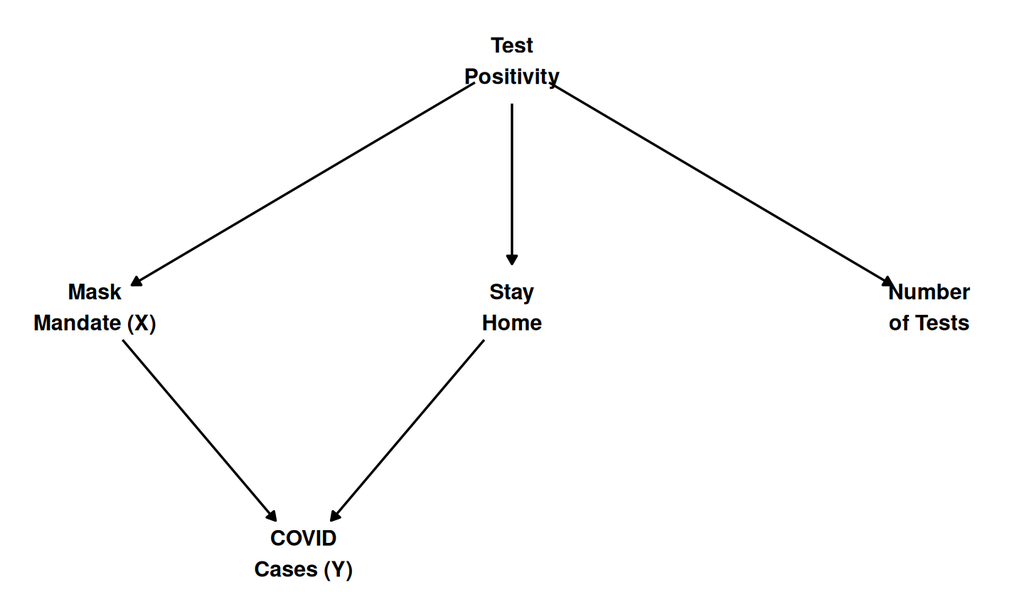

- Yes. Mandate \(\xleftarrow{}\) Positives \(\xrightarrow{}\)Stay Home\(\xrightarrow{}\)COVID Cases

## Antecedent Variable: Confounding?

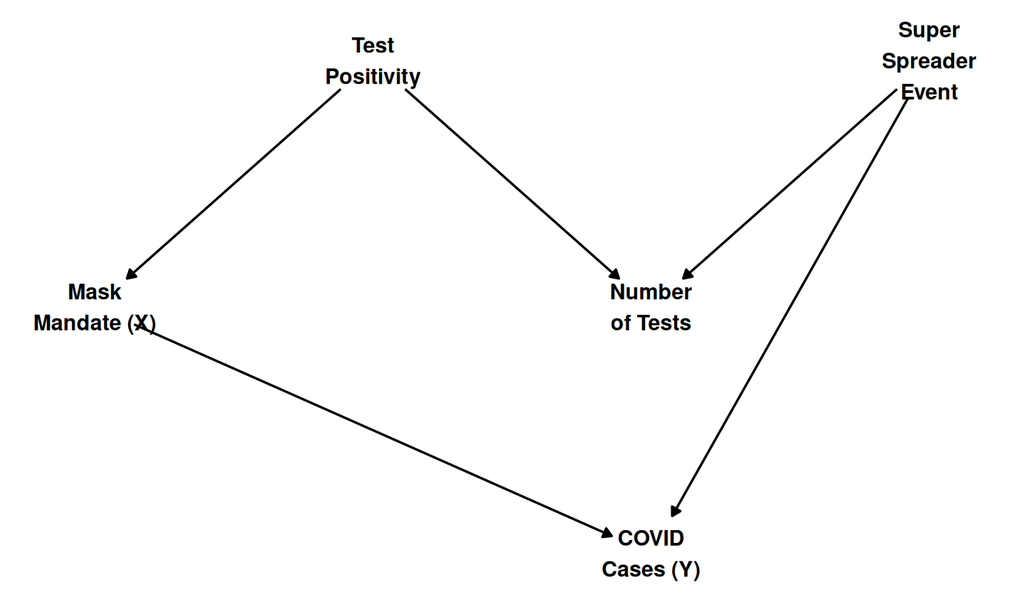

- No. No “backdoor” path; apparent “backdoor” changes directions more than once.

## Confounding?

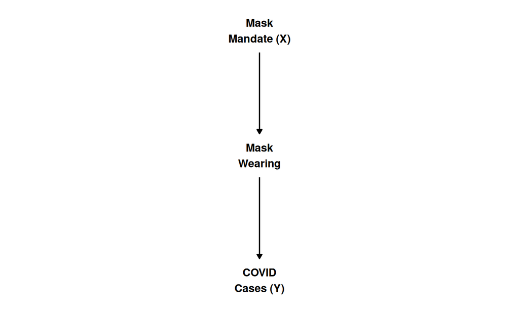

- No backdoor path. Mask mandate affects COVID **through** mask wearing.

## Intervening Variables

**intervening variable**: a variable that **affects** \(Y\) and is **affected by** \(X\).

- e.g. in this path, \(X \xrightarrow{} M \xrightarrow{} Y\), \(M\) is an intervening variable.
- intervening variables (\(M\)) **do not** produce confounding because they are on the **causal path** from \(X\) to \(Y\). They do not produce backdoor path.

## Intervening Variable

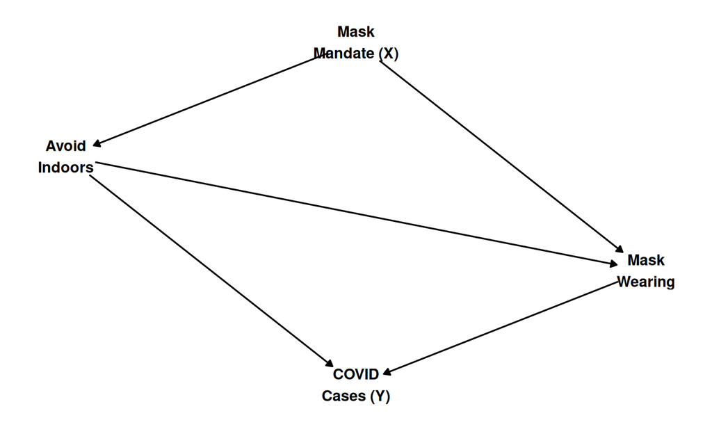

- No backdoor path. Mask mandate affects COVID **through** mask wearing, avoiding indoor spaces.

## Reverse Causality

**reverse causality** describes the situation where the **dependent variable** \(Y\) actually causes the **independent variable** \(X\).

So while we use the correlation to describe the effect of \(X\) on \(Y\): \(X \to Y\), the correlation in fact is the result of the effect of \(Y\) on \(X\): \(Y \to X\).

This is a special case of **bias** or **confounding**. (We could also draw this as “third variable”)

|  | Third Variable? | Key Attribute | Confounding? |
| --- | --- | --- | --- |
| Antecedent Variables \((W)\) | Yes | \(W \to X\) | If only **causal path** from \(W\) to \(Y\) contains \(X\): No If a **causal path** from \(W\) to \(Y\) excludes \(X\): Yes |
| Intervening Variables \((M)\) | Yes | \(X \to M \to Y\) | No |
| Reverse Causality | No | \(Y \to X\) | Yes |

## Direction of Bias

[video not shown]

## Example:

Gun violence in Miami Beach has led to state of emergency and curfew during Spring Break.

> “We haven’t been able to figure out how to stop spring break from coming,” Mr. Gelber said. “We don’t want spring break here, but they keep coming.”

### **Does reducing the number of guns reduce firearms violence (deaths)?**

- Correlation of gun ownership and firearms homicides for US states.

## Correlation: Guns and Gun Deaths

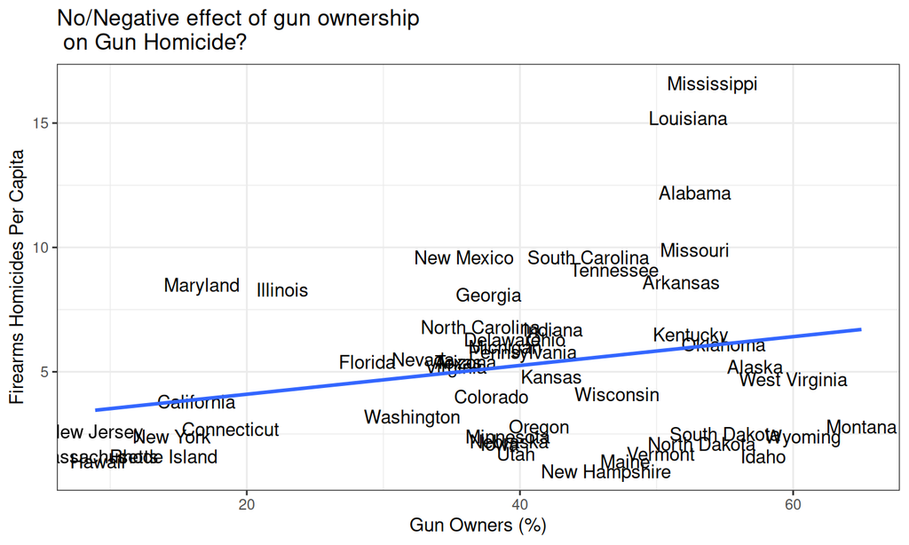

Can we conclude gun ownership **increase** firearms homicides? [hands]

## Direction of Bias

Let’s say Miami Beach is considering imposing gun control policies to reduce gun deaths during Spring Break. To make their decision, they look at the correlation on the previous slide…

If that correlation suffered from confounding (bias), how might it affect the policy decision and its consequences…

- if the confounding induced an **upward** bias (observed correlation between gun ownership and firearms deaths **more positive** than true causal relationship)?

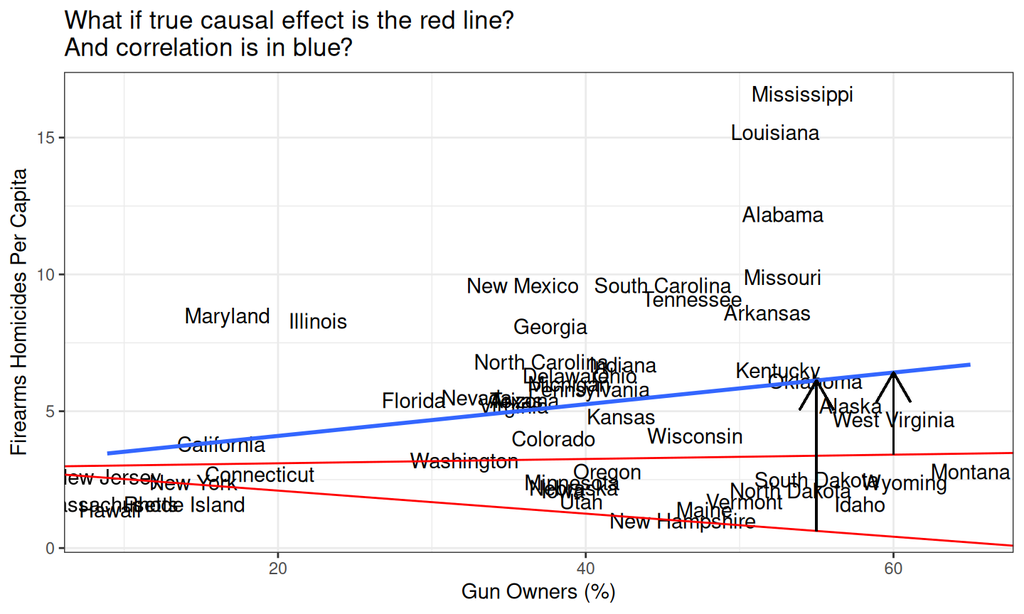

## Direction of Bias

Let’s say Miami Beach is considering imposing gun control policies to reduce gun deaths during Spring Break. To make their decision, they look at the correlation on the previous slide…

If that correlation suffered from confounding (bias), how might it affect the policy decision and its consequences…

- if the confounding induced a **downward** bias (observed correlation between gun ownership and firearms deaths **more negative** than true causal relationship)?

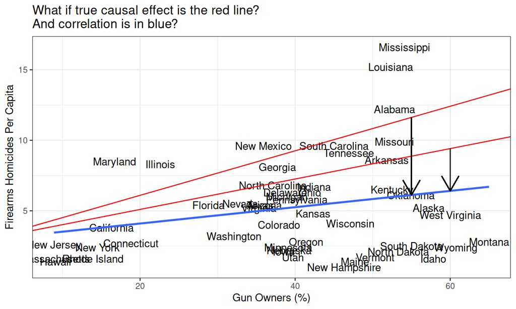

## Direction of Bias

### Why do we care?

As with measurement bias, we need to apply **weak severity** principle to judge whether bias would present a problem.

- If bias is **upward** and correlation is **positive**, true causal effect direction is **unknown**. \(\to\) Unclear what policy to choose. (Fails weak severity — confounding may lead to positive correlation even if truth is negative causal effect)
- If bias is **downward** and correlation is **positive**, true causal effect direction is **positive**. \(\to\) Definitely impose gun restrictions. (confounding makes it **harder** to find this effect: strong severity)

## Direction of Bias

As with measurement bias:

1. If confounding induces **bias** in **opposite direction of the correlation** \(\to\) true causal effect in same direction as correlation (no failure of weak severity)
2. If confounding induces **bias** in **same direction as the correlation** \(\to\) true causal effect may be zero or opposite direction of correlation (possible failure of weak severity)

In situation \((2)\): our conclusions depend on the **magnitude** or **size** of the bias induced by confounding. Not a topic for this class.

## Direction of Bias

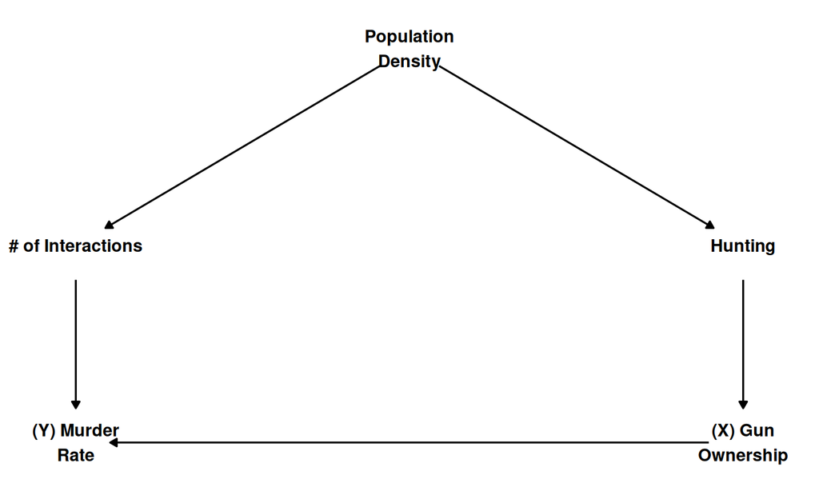

## Upward or Downward bias?

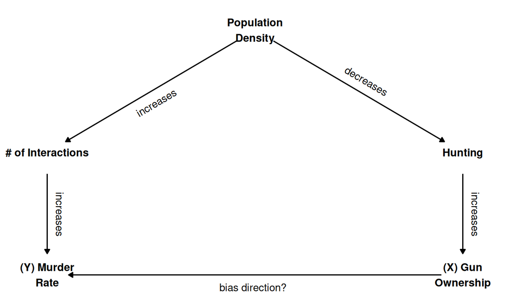

## Confounding: Direction of Bias

**Product** of **signs** on causal path from \(W \to X\) and \(W \to Y\) gives us **direction** of **bias** created by **confounding**

|  | \(W \xrightarrow{+} X\) | \(W \xrightarrow{-} X\) |
| --- | --- | --- |
| \(W \xrightarrow{+} Y\) | \(Correlation(X,Y)\) Biased (+) | \(Correlation(X,Y)\) Biased (-) |
| \(W \xrightarrow{-} Y\) | \(Correlation(X,Y)\) Biased (-) | \(Correlation(X,Y)\) Biased (+) |

\(^*:\) this only works for a **single** backdoor path; not multiple backdoor paths. Then we would need more information.

## Downward bias

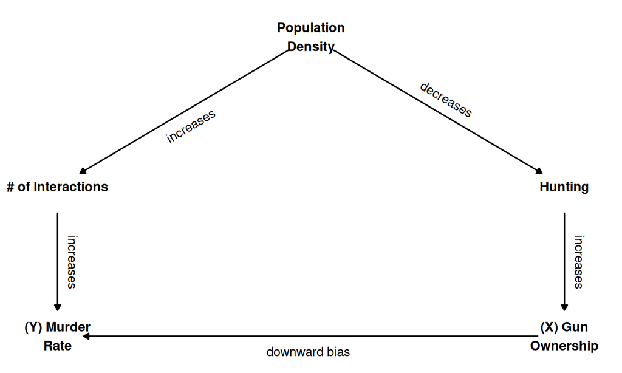

## Confounding: Direction of Bias

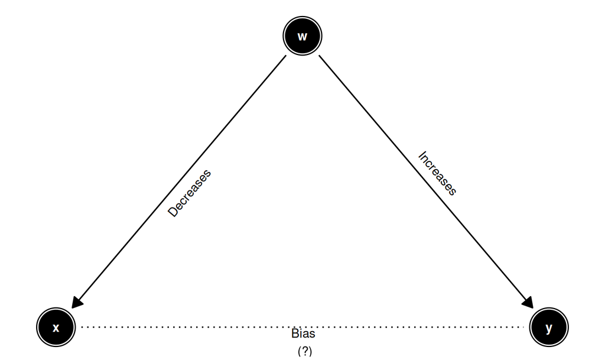

## Confounding: Direction of Bias

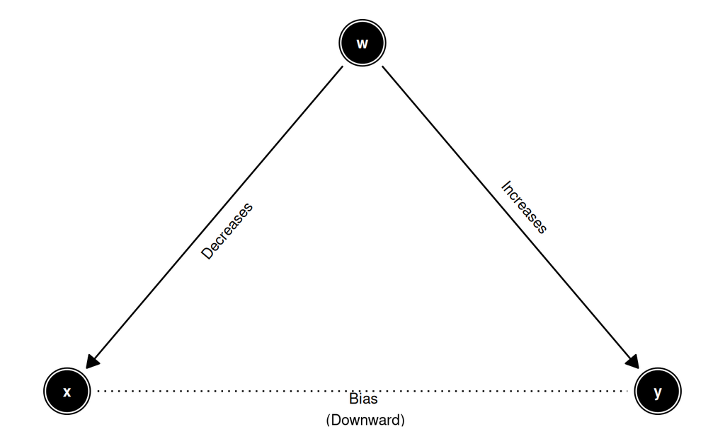

## Confounding: Direction of Bias

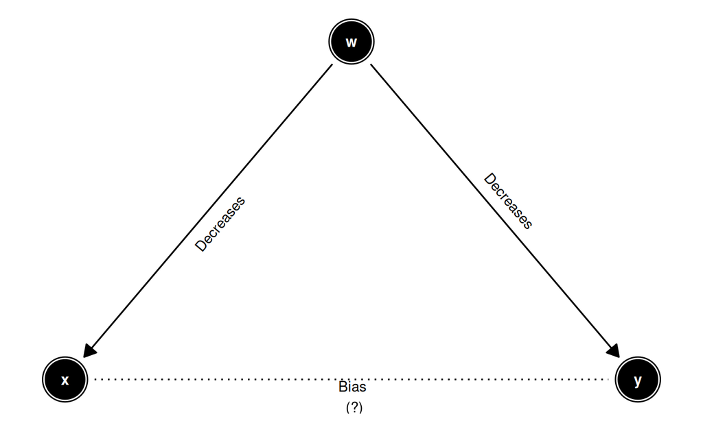

## Confounding: Direction of Bias

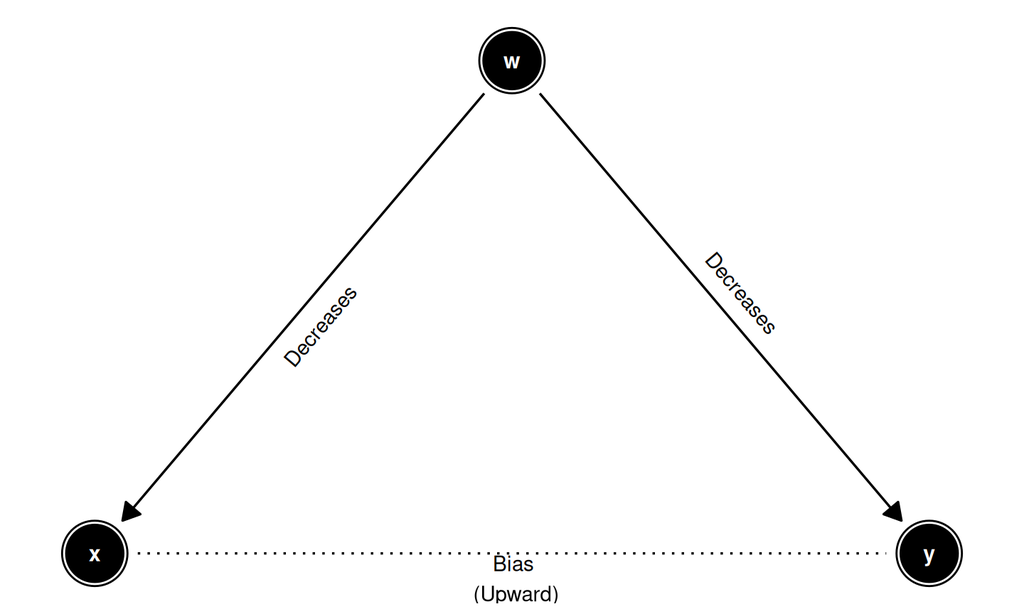

## Confounding: Direction of Bias

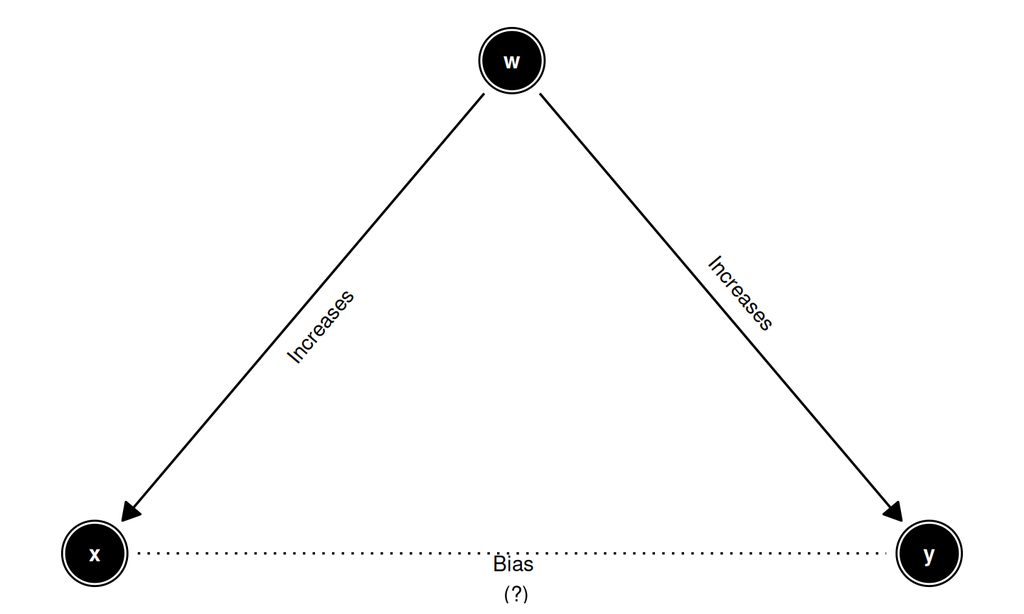

## Confounding: Direction of Bias

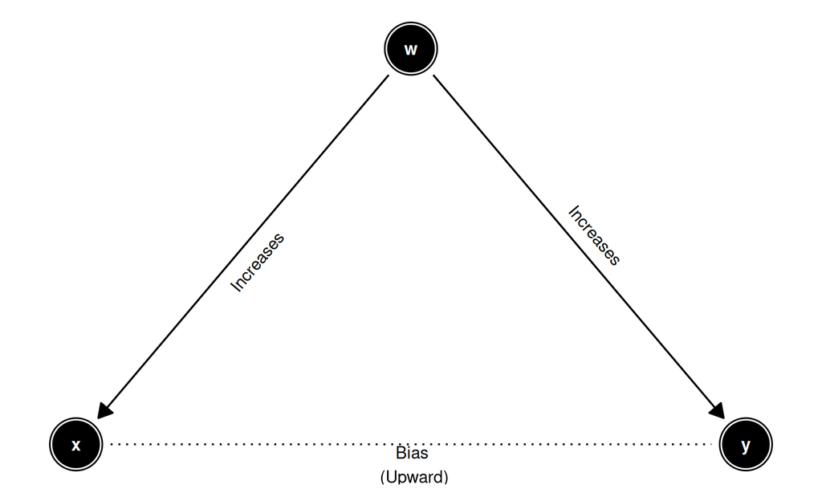

## Confounding: Direction of Bias

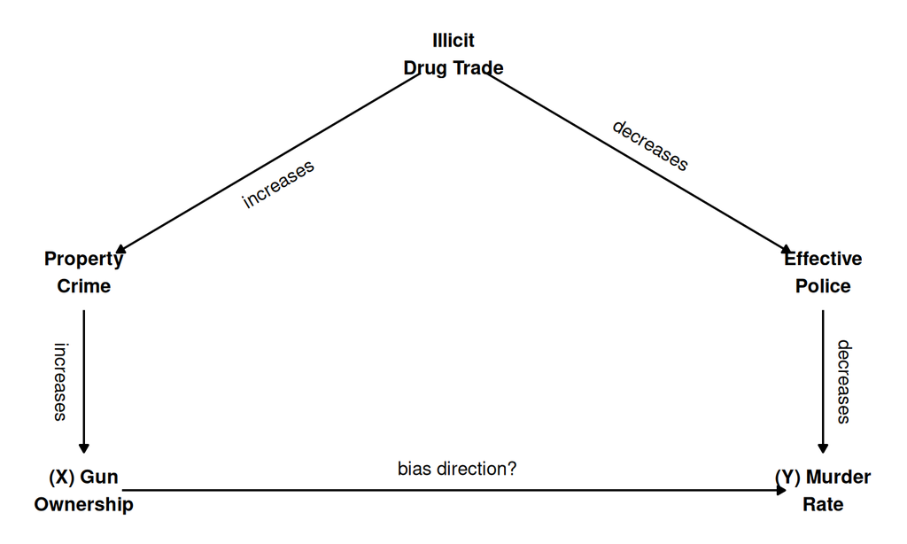

## Confounding: Direction of Bias

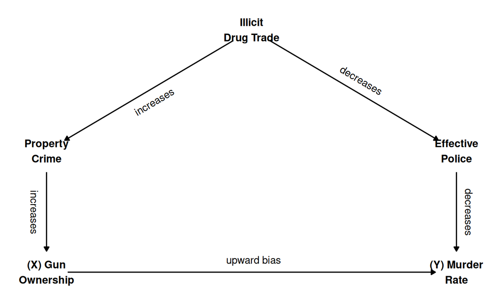

## Conclusion

## Solutions?

We now know what confounding is and how it arises…

**Consider the case of gun-control laws and gun violence:**:

- Can you think of any comparisons we can use that *guarantee* no other variable \(W\) affects \(X\) (gun ownership) and \(Y\) (gun violence)?

## Solutions?

Causal graphs point us to possible solutions:

If **something else** (\(W\)) changes \(X\) and \(Y\), leading to confounding…

1. We can use comparisons that hold \(W\) constant.
   - but do we know all relevant differences? (all causal paths?)
2. We can use comparisons that **break** the connection between \(W\) and \(X\).
   - how do we break this connection?

## Conclusion

**Confounding**

1. **bias**: observed correlation \(\neq\) true casual relationship
2. Why?
   - cases with different values of \(X\), also differ in \(\text{factual}, \color{red}{\text{counterfactual}}\) values of \(Y\)
   - when “third” variable affects \(X\), affects \(Y\) \(\to\) confounding.
3. Causal graphs help us diagnose possible sources of confounding.
4. Causal graphs help us diagnose the expected **direction** of bias (does confounding \(\to\) evidence failing weak severity?)
- Causal graphs also point to **possible solutions** for confounding